# Coupon Analysis

### Will a Customer Accept the Coupon?

**Context**

Imagine driving through town and a coupon is delivered to your cell phone for a restaraunt near where you are driving. Would you accept that coupon and take a short detour to the restaraunt? Would you accept the coupon but use it on a sunbsequent trip? Would you ignore the coupon entirely? What if the coupon was for a bar instead of a restaraunt? What about a coffee house? Would you accept a bar coupon with a minor passenger in the car? What about if it was just you and your partner in the car? Would weather impact the rate of acceptance? What about the time of day?

Obviously, proximity to the business is a factor on whether the coupon is delivered to the driver or not, but what are the factors that determine whether a driver accepts the coupon once it is delivered to them? How would you determine whether a driver is likely to accept a coupon?

**Overview**

The goal of this project is to use what you know about visualizations and probability distributions to distinguish between customers who accepted a driving coupon versus those that did not.

**Data**

This data comes to us from the UCI Machine Learning repository and was collected via a survey on Amazon Mechanical Turk. The survey describes different driving scenarios including the destination, current time, weather, passenger, etc., and then ask the person whether he will accept the coupon if he is the driver. Answers that the user will drive there ‘right away’ or ‘later before the coupon expires’ are labeled as ‘Y = 1’ and answers ‘no, I do not want the coupon’ are labeled as ‘Y = 0’. There are five different types of coupons -- less expensive restaurants (under \$20), coffee houses, carry out & take away, bar, and more expensive restaurants (\\$20 - \$50).

**Deliverables**

Your final product should be a brief report that highlights the differences between customers who did and did not accept the coupons. To explore the data you will utilize your knowledge of plotting, statistical summaries, and visualization using Python. You will publish your findings in a public facing github repository as your first portfolio piece.

### Data Description

Keep in mind that these values mentioned below are average values.

The attributes of this data set include:

1. User attributes
   - Gender: male, female
   - Age: below 21, 21 to 25, 26 to 30, etc.
   - Marital Status: single, married partner, unmarried partner, or widowed
   - Number of children: 0, 1, or more than 1
   - Education: high school, bachelors degree, associates degree, or graduate degree
   - Occupation: architecture & engineering, business & financial, etc.
   - Annual income: less than \$12500, \\$12500 - \$24999, \\$25000 - \$37499, etc.
   - Number of times that he/she goes to a bar: 0, less than 1, 1 to 3, 4 to 8 or greater than 8
   - Number of times that he/she buys takeaway food: 0, less than 1, 1 to 3, 4 to 8 or greater than 8
   - Number of times that he/she goes to a coffee house: 0, less than 1, 1 to 3, 4 to 8 or greater than 8
   - Number of times that he/she eats at a restaurant with average expense less than \$20 per person: 0, less than 1, 1 to 3, 4 to 8 or greater than 8
   - Number of times that he/she goes to a bar: 0, less than 1, 1 to 3, 4 to 8 or greater than 8
1. Contextual attributes
   - Driving destination: home, work, or no urgent destination
   - Location of user, coupon and destination: we provide a map to show the geographical location of the user, destination, and the venue, and we mark the distance between each two places with time of driving. The user can see whether the venue is in the same direction as the destination.
   - Weather: sunny, rainy, or snowy
   - Temperature: 30F, 55F, or 80F
   - Time: 10AM, 2PM, or 6PM
   - Passenger: alone, partner, kid(s), or friend(s)
1. Coupon attributes
   - time before it expires: 2 hours or one day

```python
import matplotlib.pyplot as plt
import seaborn as sns
import pandas as pd
import numpy as np
import plotly.express as ply
import warnings
import matplotlib.image as mpimg
```

### Problems

Use the prompts below to get started with your data analysis.

1. Read in the `coupons.csv` file.

```python
warnings.filterwarnings('ignore')
data = pd.read_csv('data/coupons.csv')
```

```python
data.head()
```

|  | destination | passanger | weather | temperature | time | coupon | expiration | gender | age | maritalStatus | ... | CoffeeHouse | CarryAway | RestaurantLessThan20 | Restaurant20To50 | toCoupon_GEQ5min | toCoupon_GEQ15min | toCoupon_GEQ25min | direction_same | direction_opp | Y |
| --- | --- | --- | --- | --- | --- | --- | --- | --- | --- | --- | --- | --- | --- | --- | --- | --- | --- | --- | --- | --- | --- |
| 0 | No Urgent Place | Alone | Sunny | 55 | 2PM | Restaurant(<20) | 1d | Female | 21 | Unmarried partner | ... | never | NaN | 4~8 | 1~3 | 1 | 0 | 0 | 0 | 1 | 1 |
| 1 | No Urgent Place | Friend(s) | Sunny | 80 | 10AM | Coffee House | 2h | Female | 21 | Unmarried partner | ... | never | NaN | 4~8 | 1~3 | 1 | 0 | 0 | 0 | 1 | 0 |
| 2 | No Urgent Place | Friend(s) | Sunny | 80 | 10AM | Carry out & Take away | 2h | Female | 21 | Unmarried partner | ... | never | NaN | 4~8 | 1~3 | 1 | 1 | 0 | 0 | 1 | 1 |
| 3 | No Urgent Place | Friend(s) | Sunny | 80 | 2PM | Coffee House | 2h | Female | 21 | Unmarried partner | ... | never | NaN | 4~8 | 1~3 | 1 | 1 | 0 | 0 | 1 | 0 |
| 4 | No Urgent Place | Friend(s) | Sunny | 80 | 2PM | Coffee House | 1d | Female | 21 | Unmarried partner | ... | never | NaN | 4~8 | 1~3 | 1 | 1 | 0 | 0 | 1 | 0 |

5 rows × 26 columns

1. Investigate the dataset for missing or problematic data.

```python
data.info()
```

```
<class 'pandas.core.frame.DataFrame'>
RangeIndex: 12684 entries, 0 to 12683
Data columns (total 26 columns):
 #   Column                Non-Null Count  Dtype
---  ------                --------------  -----
 0   destination           12684 non-null  object
 1   passanger             12684 non-null  object
 2   weather               12684 non-null  object
 3   temperature           12684 non-null  int64
 4   time                  12684 non-null  object
 5   coupon                12684 non-null  object
 6   expiration            12684 non-null  object
 7   gender                12684 non-null  object
 8   age                   12684 non-null  object
 9   maritalStatus         12684 non-null  object
```

[output cut: 18 more lines]

```python
data.shape
```

```
(12684, 26)
```

```python
# Check if any null values exists
data.isnull().sum()
```

```
destination                 0
passanger                   0
weather                     0
temperature                 0
time                        0
coupon                      0
expiration                  0
gender                      0
age                         0
maritalStatus               0
has_children                0
education                   0
occupation                  0
income                      0
car                     12576
Bar                       107
CoffeeHouse               217
CarryAway                 151
RestaurantLessThan20      130
Restaurant20To50          189
toCoupon_GEQ5min            0
toCoupon_GEQ15min           0
toCoupon_GEQ25min           0
direction_same              0
direction_opp               0
Y                           0
dtype: int64
```

```python
# Check all the unique values in each field
for key in data.keys():
    print ('Field:' ,key ,":",data[key].unique())
```

```
Field: destination : ['No Urgent Place' 'Home' 'Work']
Field: passanger : ['Alone' 'Friend(s)' 'Kid(s)' 'Partner']
Field: weather : ['Sunny' 'Rainy' 'Snowy']
Field: temperature : [55 80 30]
Field: time : ['2PM' '10AM' '6PM' '7AM' '10PM']
Field: coupon : ['Restaurant(<20)' 'Coffee House' 'Carry out & Take away' 'Bar'
 'Restaurant(20-50)']
Field: expiration : ['1d' '2h']
Field: gender : ['Female' 'Male']
Field: age : ['21' '46' '26' '31' '41' '50plus' '36' 'below21']
Field: maritalStatus : ['Unmarried partner' 'Single' 'Married partner' 'Divorced' 'Widowed']
Field: has_children : [1 0]
Field: education : ['Some college - no degree' 'Bachelors degree' 'Associates degree'
 'High School Graduate' 'Graduate degree (Masters or Doctorate)'
 'Some High School']
Field: occupation : ['Unemployed' 'Architecture & Engineering' 'Student'
 'Education&Training&Library' 'Healthcare Support'
 'Healthcare Practitioners & Technical' 'Sales & Related' 'Management'
 'Arts Design Entertainment Sports & Media' 'Computer & Mathematical'
 'Life Physical Social Science' 'Personal Care & Service'
 'Community & Social Services' 'Office & Administrative Support'
 'Construction & Extraction' 'Legal' 'Retired'
 'Installation Maintenance & Repair' 'Transportation & Material Moving'
 'Business & Financial' 'Protective Service'
 'Food Preparation & Serving Related' 'Production Occupations'
 'Building & Grounds Cleaning & Maintenance' 'Farming Fishing & Forestry']
Field: income : ['$37500 - $49999' '$62500 - $74999' '$12500 - $24999' '$75000 - $87499'
 '$50000 - $62499' '$25000 - $37499' '$100000 or More' '$87500 - $99999'
 'Less than $12500']
Field: car : [nan 'Scooter and motorcycle' 'crossover' 'Mazda5' 'do not drive'
 'Car that is too old to install Onstar :D']
Field: Bar : ['never' 'less1' '1~3' 'gt8' nan '4~8']
Field: CoffeeHouse : ['never' 'less1' '4~8' '1~3' 'gt8' nan]
Field: CarryAway : [nan '4~8' '1~3' 'gt8' 'less1' 'never']
Field: RestaurantLessThan20 : ['4~8' '1~3' 'less1' 'gt8' nan 'never']
Field: Restaurant20To50 : ['1~3' 'less1' 'never' 'gt8' '4~8' nan]
Field: toCoupon_GEQ5min : [1]
Field: toCoupon_GEQ15min : [0 1]
Field: toCoupon_GEQ25min : [0 1]
Field: direction_same : [0 1]
Field: direction_opp : [1 0]
Field: Y : [1 0]
```

1. Decide what to do about your missing data -- drop, replace, other...

```python
#About 99% of the data in the car field is empty
#We can drop this field
data.drop(columns=['car'],inplace=True)
data.shape
```

```
(12684, 25)
```

```python
# Replace null values to never
data.fillna({'Bar':'never','CoffeeHouse':'never','CarryAway':'never',
                 'RestaurantLessThan20':'never','Restaurant20To50':'never'},inplace=True)
data.replace('never','0',inplace=True)
data.replace('less1','<1',inplace=True)
data.replace('gr8','>8',inplace=True)
data.isnull().sum()
```

```
destination             0
passanger               0
weather                 0
temperature             0
time                    0
coupon                  0
expiration              0
gender                  0
age                     0
maritalStatus           0
has_children            0
education               0
occupation              0
income                  0
Bar                     0
CoffeeHouse             0
CarryAway               0
RestaurantLessThan20    0
Restaurant20To50        0
toCoupon_GEQ5min        0
toCoupon_GEQ15min       0
toCoupon_GEQ25min       0
direction_same          0
direction_opp           0
Y                       0
dtype: int64
```

1. What proportion of the total observations chose to accept the coupon?

```python
coupon_acceptance_perc = data['Y'].mean()
print('Coupon Acceptance Rate:',round(coupon_acceptance_perc,2))
```

```
Coupon Acceptance Rate: 0.57
```

1. Use a bar plot to visualize the `coupon` column.

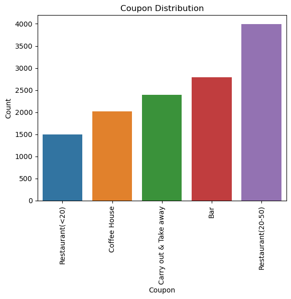

```python
coupon_barplt = sns.barplot(x=data['coupon'].unique(),y=data['coupon'].value_counts(ascending=True))
plt.xticks(rotation=90)
plt.xlabel('Coupon')
plt.ylabel('Count')
plt.title('Coupon Distribution')
```

1. Use a histogram to visualize the temperature column.

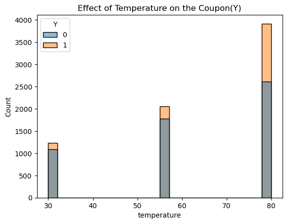

```python
sns.histplot(data=data,x='temperature',hue='Y')
plt.title('Effect of Temperature on the Coupon(Y)')
```

Finding: Higher the temperature, more coupons are available to use for the customers. Also more coupons being used in the high temperature.

**Investigating the Bar Coupons**

Now, we will lead you through an exploration of just the bar related coupons.

1. Create a new `DataFrame` that contains just the bar coupons.

```python
bar_df = data.query('coupon=="Bar"')
```

1. What proportion of bar coupons were accepted?

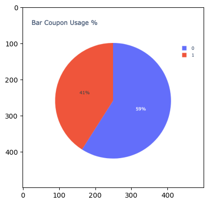

```python
#Average of bar coupon accepted
avg_bar_coupon = bar_df.groupby('Y').size().reset_index()
fig = ply.pie(avg_bar_coupon, values=0, title='Bar Coupon Usage %',
              names='Y')
fig.update_layout(
    autosize=False,
    width=500,
    height=500
)
#Save the image
fig.write_image("images/avg_bar.png")
#open the image using plotly
img = mpimg.imread("images/avg_bar.png")
plt.imshow(img)
```

1. Compare the acceptance rate between those who went to a bar 3 or fewer times a month to those who went more.

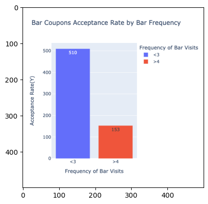

```python
# Remove customers that did not used Bar coupons
bar_coupon = bar_df[bar_df['Bar'] != '0']
# Replace '1~3' and '<1' to '<3'
bar_coupon = bar_coupon.replace('<1','<3').replace('1~3','<3')
# Replace '4~8' and 'gt8' to '>4'
bar_coupon = bar_coupon.replace('gt8','>4').replace('4~8','>4')
# Average coupons acceptance by bar type
avg_bar_coupon = bar_coupon.groupby('Bar')[['Y']].sum().reset_index()
bar_df_barplt = ply.bar(avg_bar_coupon, x="Bar", y="Y",  text_auto=True,
                       labels = {'Y':'Acceptance Rate(Y)','Bar':'Frequency of Bar Visits'},title = 'Bar Coupons Acceptance Rate by Bar Frequency',
                       color='Bar')
bar_df_barplt.update_layout(
    autosize=False,
    width=500,
    height=500
)
#Save the image
bar_df_barplt.write_image("images/bar_df_barplt.png")
#open the image using plotly
img1 = mpimg.imread("images/bar_df_barplt.png")
plt.imshow(img1)
```

1. Compare the acceptance rate between drivers who go to a bar more than once a month and are over the age of 25 to the all others. Is there a difference?

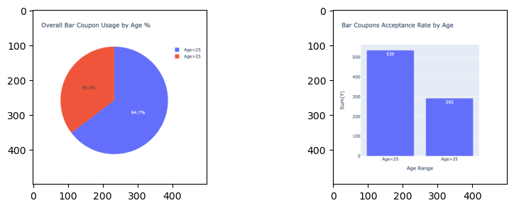

```python
#Boolean field that shows whether the bar coupon visit is more than once and age>25

bar_df['bar_age_over_25_gr1'] =((bar_df['Bar'] != "0" ) & \
                                (bar_df['Bar'] != "<1" ) &\
                                (bar_df['age']!= "21") & \
                                (bar_df['age']!="below21") &\
                                 (bar_df['Y']==1))
bar_df_age= bar_df.groupby('bar_age_over_25_gr1')['Y'].sum().reset_index()
bar_df_age['average'] = bar_df_age['Y']/bar_df.shape[0]
bar_df_age = bar_df_age.replace(True, 'Age>25').replace(False,'Age<25')
fig1 = ply.pie(bar_df_age,names = "bar_age_over_25_gr1",
            values='average',
            title='Overall Bar Coupon Usage by Age %'
       )

fig1.update_layout(
    autosize=False,
    width=500,
    height=500
)
fig2 = ply.bar(bar_df_age,
                        x="bar_age_over_25_gr1", y="Y",  text_auto=True,
                        labels = {'Y':'Sum(Y)',
                                  'bar_age_over_25_gr1':'Age Range'},
                        title = 'Bar Coupons Acceptance Rate by Age')

fig2.update_layout(
    autosize=False,
    width=500,
    height=500
)

#Save the image
fig1.write_image("images/bar_df_pieplt.png")

#Save the image
fig2.write_image("images/bar_df_agebarplt.png")
# To plot 2 charts side by side subplot library is being used
# REFERENCED FROM :
# https://www.geeksforgeeks.org/how-to-display-multiple-images-in-one-figure-correctly-in-matplotlib/
# create figure
fig = plt.figure(figsize=(10, 7))
fig.add_subplot(2, 2, 1)
#open the image using plotly
img2 = mpimg.imread("images/bar_df_pieplt.png")
plt.imshow(img2)
fig.add_subplot(2, 2, 2)

#open the image using plotly
img3 = mpimg.imread("images/bar_df_agebarplt.png")
plt.imshow(img3)
```

1. Use the same process to compare the acceptance rate between drivers who go to bars more than once a month and had passengers that were not a kid and had occupations other than farming, fishing, or forestry.

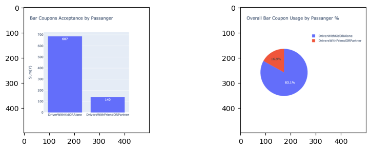

```python
# Filtering the dataset based on the conditions
bar_df['bar_with_passenger'] =(bar_df['Bar'] != "0" ) & \
                                (bar_df['Bar'] != "<1" ) &\
                                (bar_df['passanger']!= "Kid(s)") & \
                                (bar_df['passanger']!="Alone") &\
                                (bar_df['occupation']!='Farming Fishing & Forestry') &\
                                 (bar_df['Y']==1)
# Grouping the result to get the total count of customers who goes to the bar
bar_df_avg_passenger = bar_df[['bar_with_passenger','Y']].groupby('bar_with_passenger')['Y'].sum().reset_index()
bar_df_avg_passenger['average'] = bar_df_avg_passenger['Y']/bar_df.shape[0]
#Replacing the boolean values to understandable text
bar_df_avg_passenger = bar_df_avg_passenger.replace(True, 'DriversWithFriendORPartner')\
                                .replace(False,'DriverWithKidORAlone')
fig3 = ply.pie(bar_df_avg_passenger,names = "bar_with_passenger",
            values='average',
            title='Overall Bar Coupon Usage by Passanger %'
       )

fig3.update_layout(
    autosize=False,
    width=500,
    height=500
)
bar_df_avg_passenger = ply.bar(bar_df_avg_passenger,
                                x="bar_with_passenger", y="Y",  text_auto=True,
                                labels = {'Y':'Sum(Y)','bar_with_passenger':''},
                                title = 'Bar Coupons Acceptance by Passanger')
bar_df_avg_passenger.update_layout(
    autosize=False,
    width=500,
    height=500
)
#Save the image
fig3.write_image("images/bar_df_psr_overall.png")

#Save the image
bar_df_avg_passenger.write_image("images/bar_df_psr_avg.png")
# To plot 2 charts side by side subplot library is being used
# REFERENCED FROM :
# https://www.geeksforgeeks.org/how-to-display-multiple-images-in-one-figure-correctly-in-matplotlib/
# create figure
fig = plt.figure(figsize=(10, 7))
fig.add_subplot(2, 2, 1)
#open the image using plotly
img2 = mpimg.imread("images/bar_df_psr_avg.png")
plt.imshow(img2)
fig.add_subplot(2, 2, 2)

#open the image using plotly
img3 = mpimg.imread("images/bar_df_psr_overall.png")
plt.imshow(img3)
```

1. Compare the acceptance rates between those drivers who:
- go to bars more than once a month, had passengers that were not a kid, and were not widowed *OR*
- go to bars more than once a month and are under the age of 30 *OR*
- go to cheap restaurants more than 4 times a month and income is less than 50K.

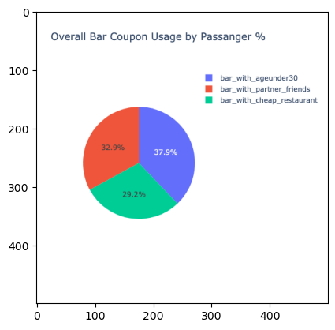

```python
bar_df['bar_with_partner_friends'] =(bar_df['Bar'] != "0" ) & \
                                (bar_df['Bar'] != "<1" ) &\
                                (bar_df['passanger']!= "Kid(s)") & \
                                (bar_df['passanger']!="Alone") &\
                                (bar_df['maritalStatus']!='Widowed') &\
                                 (bar_df['Y']==1)
bar_df['bar_with_ageunder30'] =(bar_df['Bar'] != "0" ) & \
                                (bar_df['Bar'] != "<1" ) &\
                                (~bar_df['age'].isin(['21','26','below21'])) & \
                                 (bar_df['Y']==1)
bar_df['bar_with_cheap_restaurant'] =(bar_df['income'].isin(['$12500 - $24999','$37500 - $49999'\
                                                     ,'$25000 - $37499'])&\
                                (bar_df['RestaurantLessThan20'].isin(['4~8','gt8'])) & \
                                 (bar_df['Y']==1))
bar_coupons_df = bar_df[['bar_with_partner_friends','bar_with_ageunder30','bar_with_cheap_restaurant']]
fig3 = ply.pie(bar_df,names = bar_coupons_df.columns,
            values=bar_coupons_df.sum(),
            title='Overall Bar Coupon Usage by Passanger %'
       )

fig3.update_layout(
    autosize=False,
    width=500,
    height=500
)
#Save the image
fig3.write_image("images/bar_df_psr.png")
#open the image using plotly
img3 = mpimg.imread("images/bar_df_psr.png")
plt.imshow(img3)
```

1. Based on these observations, what do you hypothesize about drivers who accepted the bar coupons?

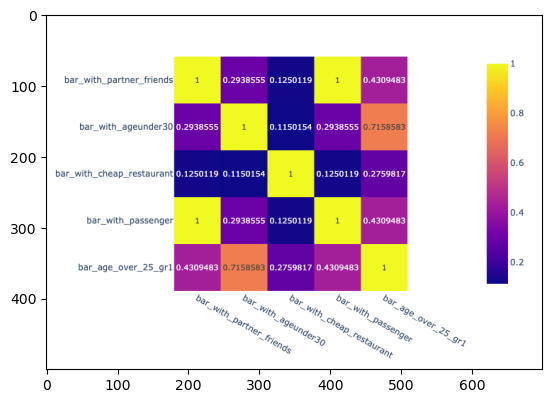

```python
bar_observations = bar_df[['bar_with_partner_friends','bar_with_ageunder30',
                           'bar_with_cheap_restaurant','bar_with_passenger','bar_age_over_25_gr1']]\
                            .replace(True,1).replace(False,0)
fig = ply.imshow(bar_observations.corr(),text_auto=True)
#Save the image
fig.write_image("images/bar_df_overall.png")
#open the image using plotly
img4 = mpimg.imread("images/bar_df_overall.png")
plt.imshow(img4)
```

### Independent Investigation

Using the bar coupon example as motivation, you are to explore one of the other coupon groups and try to determine the characteristics of passengers who accept the coupons.

```
2. Get the age of the customers who accepted the coupon (Y=1)
```

```python
rst_df = data.query('coupon=="Restaurant(<20)"')
```

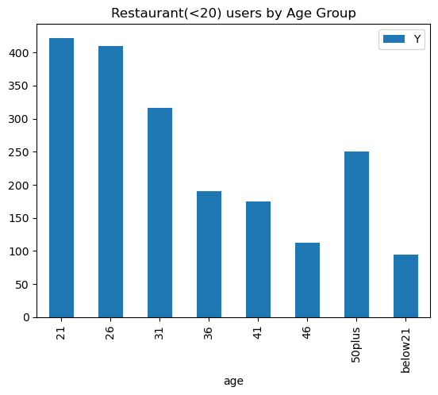

```python
rst_df.groupby('age')[['age','Y']].sum('Y').plot(kind='bar',title = 'Restaurant(<20) users by Age Group')
```

Findings : Customers with Age between 21 and 31 uses the Restaurant(<20) coupons.

How to promote coupon based on the age group?

```
[Text(0.5, 1.0, 'Coupon usage by Age group')]
```

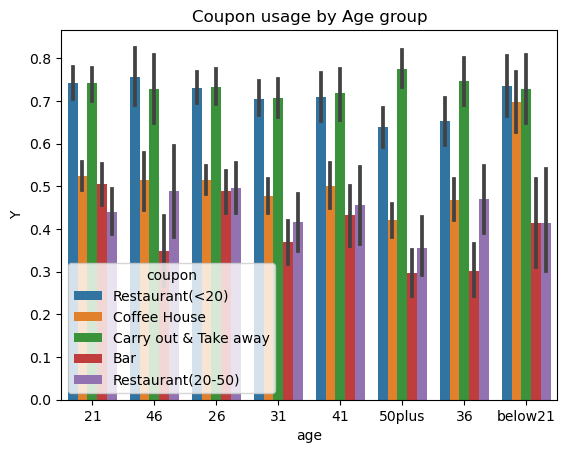

```python
sns.barplot(x = 'age',
            y = 'Y',
            hue = 'coupon',
            data = data).set(
            title = 'Coupon usage by Age group'
           )
```

Findings :

1. Customers with the "Age over 50" uses "Carry Out & Take away" coupons more
2. Customers with the 'Age below 21" uses "Restaurant(<20)" coupons more
3. Coffee House coupons are more used with the Age below 21
4. Age group between 21-26 uses more Bar coupons

How does the driving direction affect the coupon usage?

```python
data[['Y','direction_opp','direction_same']].groupby('Y').sum().reset_index()
```

|  | Y | direction_opp | direction_same |
| --- | --- | --- | --- |
| 0 | 0 | 4336 | 1138 |
| 1 | 1 | 5624 | 1586 |

Findings : It is not guaranteed that driving direction affect the coupon acceptance.

```python
coupon_df = data[['toCoupon_GEQ5min','toCoupon_GEQ15min','toCoupon_GEQ25min','Y']].groupby('Y').sum().reset_index()
coupon_df
```

|  | Y | toCoupon_GEQ5min | toCoupon_GEQ15min | toCoupon_GEQ25min |
| --- | --- | --- | --- | --- |
| 0 | 0 | 5474 | 3328 | 863 |
| 1 | 1 | 7210 | 3794 | 648 |

Findings: Coupons acceptance rate is high within 5minutes of the coupon received by the customer. Chances of accepting the coupon is less after 15 mins.